# Comparativo ipeaplot

2023-08-14

O [**ipeaplot**](https://github.com/ipea-datalab/ipeaplot) é um pacote computacional desenvolvido para facilitar a padronização de cores e formatação gráfica para submissões de textos para discussão (TD) e artigos para a revista do Instituto de Pesquisa Econômica Aplicada (IPEA). Este pacote fornece aos usuários ferramentas e funções que simplificam o processo de aplicação de esquemas de cores e estilos gráficos consistentes em seu trabalho, garantindo a conformidade com os requisitos e diretrizes da revista IPEA. Ao usar o **ipeaplot**, os usuários podem facilmente obter envios de texto visualmente atraentes e formatados profissionalmente para o IPEA. (veja informações detalhadas abaixo).. Esta vinheta apresenta uma introdução rápida ao **ipeaplot**.

## Instalação

Você pode instalar a versão de desenvolvimento do ipeaplot no github:

```r
# Development version
utils::remove.packages('ipeaplot')
remotes::install_github("ipeadata-lab/ipeaplot")
```

Leitura de bibliotecas

```r
library(ipeaplot)
library(ggplot2)
library(dplyr)
library(abjData)
library(geobr)
library(reshape)
library(knitr)
```

Leitura dos dados

```r
######## GRAFICO 1
Ano <- factor(c(2000,2005,2010,2015,2020,2025,2030,2035,2040,2045,2050))
Populacao <- c(6.1,6.5,6.9,7.3,7.7,8.0,8.3,8.6,8.9,9.1,9.3)
labels <- as.character(Populacao)
labels <- gsub("." , "," , labels, fixed=T)
base_graf1 <- data.frame(Ano,Populacao,labels)

######## GRAFICO 2
Assunto <- c('Produção Técnica do Ipea','Questões Administrativas',
             'Questões de Ouvidoria','Serviços Ipea','Questões Improcedentes')
Freq <- c(588,680,434,285,407)
percentual <- round(Freq/sum(Freq),2)*100
base_graf2 <- data.frame(Assunto,Freq,percentual)

####### GRAFICO 3
Ano <- factor(c(1950,   1951,   1952,   1953,   1954,   1955,   1956,   1957,   1958,   1959,   1960,   1961,   1962,   1963,   1964,   1965,   1966,   1967,   1968,   1969,   1970,   1971,   1972,   1973,   1974,   1975,   1976,   1977,   1978,   1979,   1980,   1981,   1982,   1983,   1984,   1985,   1986,   1987,   1988,   1989,   1990,   1991,   1992,   1993,   1994,   1995,   1996,   1997,   1998,   1999,   2000,   2001,   2002,   2003,   2004,   2005,   2006,   2007,   2008,   2009,   2010,   2011,   2012,   2013,   2014))
Populacao<- c( 1.850116458, 1.791417471,    1.760491225,    1.751060624,    1.757374206,    1.773968217,    1.795950884,    1.81926587, 1.840930397,    1.860403495,    1.879485845,    1.90178203, 1.931384556,    1.96968284, 2.011263472, 2.052385316,   2.083875031,    2.098137208,    2.091095193,    2.06831928, 2.043373483,    2.018775478,    1.985792138,    1.944170268,    1.898407101,    1.850171278,    1.807798778,    1.779963926,    1.770930519,    1.77532254, 1.778741317,    1.77934085, 1.787498884,    1.803957627,    1.823106379,    1.844715108,    1.856490979,    1.844087147,    1.801286156,    1.7376904,  1.669804195,    1.607655387,    1.548374095,    1.4949701,  1.447065626,    1.399607643, 1.354384982,   1.318725392,    1.294773864,    1.279786607,    1.268049775,    1.257045807,    1.248951736,    1.243210965,    1.239058923,    1.236026043,    1.23309632, 1.229128787,    1.223387196,    1.215887987,    1.207869122,    1.198749205,    1.186540058,    1.170622969,    1.151783904)
labels <- as.character(Populacao)
labels <- gsub("." , "," , labels, fixed=T)
base_graf3<- data.frame(Ano,Populacao, labels)

######## GRAFICO 4
# Valores Hipoteticos
Pais <- factor(c("Ìndia","Japão","Alemanha","Reino Unido","França",
                 "Arábia Saudita","Rússia","China","Estados Unidos"))
Gasto <- c(40,50,50,60,70,40,90,207,640)
base_graf4<- data.frame(Pais,Gasto)
base_graf4$pos <- ifelse(base_graf4$Pais == 'Estados Unidos',2,1)

library(dplyr)
base_graf4 <- base_graf4 %>%
  group_by(pos) %>%
  mutate(total = sum(Gasto))

######## GRAFICO 5
Ano <- seq(2009,2020,1)
Exabytes <- c(130,360,750,1400,3100,6000,10000,14000,19000,25000,31500,40000)

base_graf5 <- data.frame(Ano,Exabytes)

######## GRAFICO 6

Ano <- seq(2004,2013,1)
Mundo <- c(4.2,3.8,4.1,4,1.5,-2,4,2.9,2.4,2.1)
UE <- c(2.6,2.2,3.4,3.2,0.6,-4.6,2.1,1.7,-0.4,0)

base_graf6 <- data.frame(Ano,Mundo,UE)
base_graf6<- melt(base_graf6, id=c("Ano"))

######## GRAFICO 7
pais <- c("Áustria","Bélgica","Bulgária","Croácia","Chipre","República Tcheca","Dinamarca",
          "Estônia","Finlândia","França","Alemanha","Grécia","Hungria","Irlanda","Itália",
          "Letônia","Lituânia","Luxemburgo","Malta","Holanda","Polônia","Portugal","România",
          "Eslováquia","Eslovênia","Espanha","Suécia","Reino Unido")

petroleo <- c(90,100,97,72,104,96,-37,60,90,97,96,100,
              81,102,89,104,90,98,98,97,96,98,52,89,107,96,95,38)

base_graf7 <- data.frame(pais,petroleo)

######## GRAFICO 8
pais <- c("África do Sul","Brasil","Federação Russa",
          "China","Índia","OCDE")

final <- c(0.695,0.55,0.43,0.413,0.38,0.315)

inicio <- c(0.67,0.61,0.4,0.33,0.32,0.297)

base_graf8 <- data.frame(pais,final,inicio)

######## GRAFICO 9
base_graf9 <- data.table::fread('https://github.com/ipeadata-lab/ipeaplot/files/12239277/dados_grafico9.csv', dec = ",", encoding = 'Latin-1')

######## GRAFICO 10
base_graf10 <- data.table::fread('https://github.com/ipeadata-lab/ipeaplot/files/12239278/dados_grafico10.csv', dec = ",", encoding = 'Latin-1')

######## Salvando graficos no formato Rdata
save(base_graf1,base_graf2,base_graf3,base_graf5,base_graf6,base_graf7,base_graf8,base_graf9, base_graf10,
     file='bases_de_dados.Rdata')
```

Gráfico 1 - Original

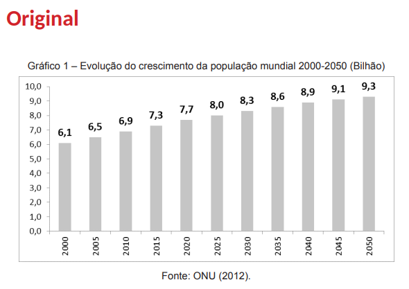

```r
knitr::include_graphics("https://github.com/ipeadata-lab/ipeaplot/blob/master/tests/compara_editorial/prints_original/grafico1.png?raw=true")
```

Gráfico 1 - Padrão ipea

```r
knitr::include_graphics("https://github.com/ipeadata-lab/ipeaplot/blob/master/tests/compara_editorial/prints_ipea_theme/grafico_1.pdf")
```

[figure not shown]

Gráfico 2 - Original

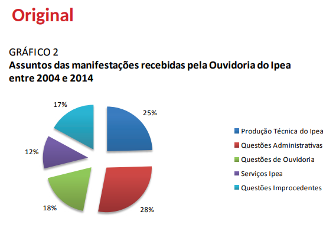

```r
knitr::include_graphics("https://github.com/ipeadata-lab/ipeaplot/blob/master/tests/compara_editorial/prints_original/grafico2.png?raw=true")
```

Gráfico 2 - Padrão Ipea

```r
y.breaks <- cumsum(base_graf2$percentual) - (base_graf2$percentual)/2
y.breaks
```

```
#> [1] 12.5 39.0 62.0 77.0 91.5
```

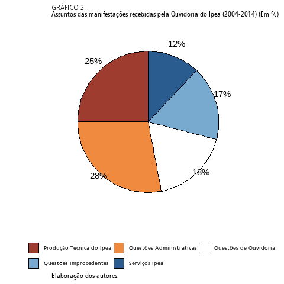

```r
graf2 <- ggplot(base_graf2, aes(x='', y=percentual, fill=Assunto))+
  geom_bar(width = 1, stat = "identity", color= 'black')+
  coord_polar("y", start=0) +
  labs(x="",
       y="",
       fill = "",
       title="GRÁFICO 2",
       subtitle="Assuntos das manifestações recebidas pela Ouvidoria do Ipea (2004-2014) (Em %)",
       caption = 'Elaboração dos autores.') +
  theme_ipea(legend.position="bottom", axis = 'none', text = F, geom = 'pie') +
  scale_fill_ipea(discrete = T,palette = 'Orange-Blue') +
  insert_text(label = 'percentual', show_percents = T, pie_plot = T)


graf2
```

Gráfico 3 - Original

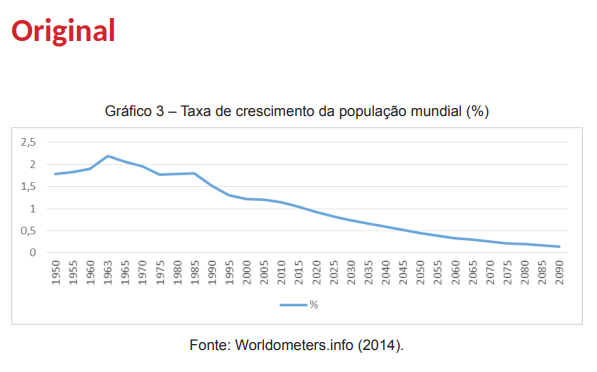

```r
knitr::include_graphics("https://github.com/ipeadata-lab/ipeaplot/blob/master/tests/compara_editorial/prints_original/grafico3.png?raw=true")
```

Gráfico 3 - Padrão Ipea

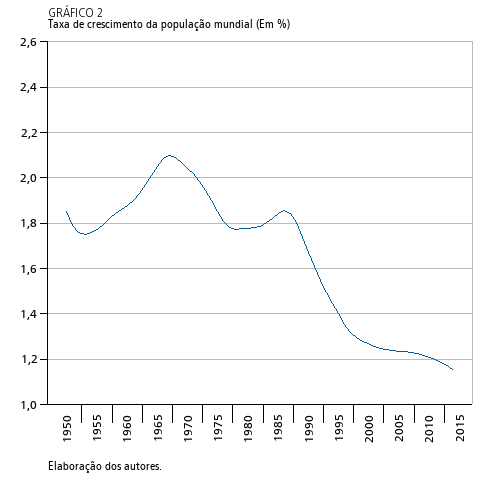

```r
base_graf3$Ano <- as.numeric(as.character(base_graf3$Ano))
ref <- (subset(base_graf3,substr(Ano,4,4) %in% c('5','0')))

graf3 <- ggplot(base_graf3, aes(x=Ano, y=Populacao, group = 1))+
  geom_line(color = '#015f96') +
  labs(x="",
       y="",
       fill = "",
       title="GRÁFICO 2",
       subtitle="Taxa de crescimento da população mundial (Em %)",
       caption = 'Elaboração dos autores.') +
  theme_ipea(y = 1 , yend = 2.6, x_breaks = 16, angle = 90, adjust_ticks = T) +
  geom_rug(data = ref, aes(x = Ano+2.5),inherit.aes = FALSE,
           outside = TRUE, sides = "b", length = unit(5, "mm"), linewidth = 0.25) +
  coord_cartesian(clip = "off")

graf3
```

Gráfico 4 - Padrão Original

[figure not shown]

```r
knitr::include_graphics("https://github.com/ipeadata-lab/ipeaplot/blob/master/tests/compara_editorial/prints_original/grafico4.png?raw=true")
```

Gráfico 4 - Padrão Ipea

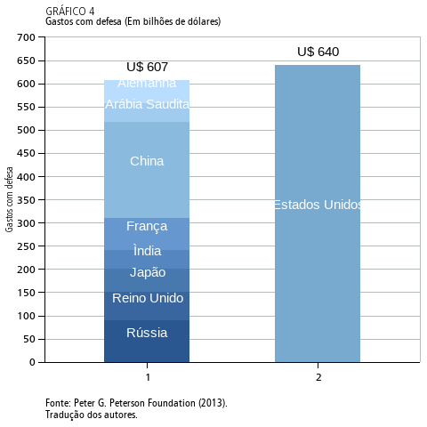

```r
temp <- base_graf4 %>% distinct(pos, .keep_all = T)
graf4 <- ggplot(base_graf4, aes(x= as.character(pos), y=Gasto, fill=Pais,
                                label = total))+
  geom_bar(width = 0.5, stat = "identity", color= NA) +
  labs(x="",
       y="Gastos com defesa",
       fill = "",
       title="GRÁFICO 4",
       subtitle="Gastos com defesa (Em bilhões de dólares)",
       caption = 'Fonte: Peter G. Peterson Foundation (2013).\nTradução dos autores.') +
  scale_fill_ipea(discrete = T) +
  insert_text(label = "Pais", color = 'white') +
  geom_text(data = temp, aes(y = total ,label = paste0("U$ ",total)), vjust = -1) +
  theme_ipea(legend.position="none",geom = 'bar',
             yend = 700)

graf4
```

Gráfico 5 - Original

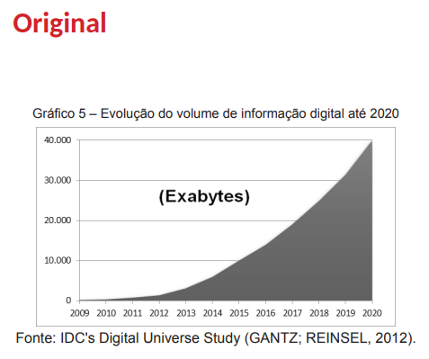

```r
knitr::include_graphics("https://github.com/ipeadata-lab/ipeaplot/blob/master/tests/compara_editorial/prints_original/grafico5.png?raw=true")
```

Gráfico 5 - Padrão Ipea

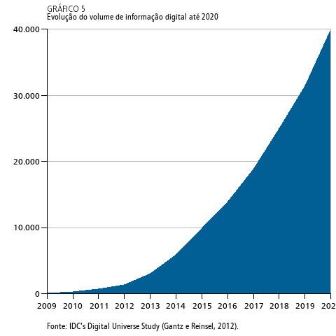

```r
graf5 <- ggplot(base_graf5, aes(x=Ano)) +
  geom_ribbon(aes(ymin=0, ymax=Exabytes), fill = "#015f96")+
  labs(x="",
       y="",
       fill = "",
       title="GRÁFICO 5",
       subtitle="Evolução do volume de informação digital até 2020",
       caption = 'Fonte: IDC’s Digital Universe Study (Gantz e Reinsel, 2012).') +
  theme_ipea(legend.position="none",geom = 'bar',
             x_breaks = 10, y_breaks = 4)
graf5
```

Gráfico 6 - Original

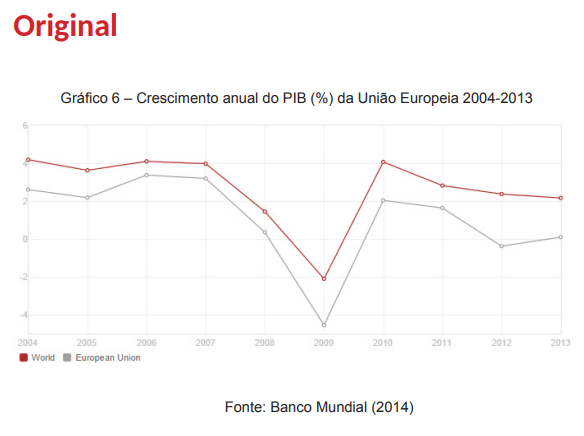

```r
knitr::include_graphics("https://github.com/ipeadata-lab/ipeaplot/blob/master/tests/compara_editorial/prints_original/grafico6.png?raw=true")
```

Gráfico 6 - Padrão Ipea

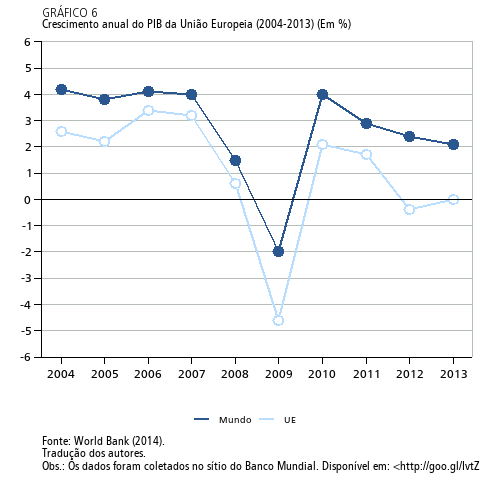

```r
graf6 <- ggplot(base_graf6, aes(Ano, value, group=variable, color=variable))+
  geom_line(size=1)+
  geom_point(aes(shape=variable, fill = variable),
             size=3, stroke=1.5, show.legend = F)+
  labs(x="",
       y="",
       color = "",
       title="GRÁFICO 6",
       subtitle="Crescimento anual do PIB da União Europeia (2004-2013) (Em %)",
       caption = 'Fonte: World Bank (2014).\nTradução dos autores.\nObs.: Os dados foram coletados no sítio do Banco Mundial. Disponível em: <http://goo.gl/IvtZ1a>. Acesso em: 26 set. 2014.') +
  theme_ipea(y = -6,yend = 6,
             x_breaks = 8, y_breaks = 10, legend.position = 'bottom') +
  scale_color_ipea(palette_direction = -1, discrete = T, hline = 0) +
  scale_shape_manual(values = c(19, 21)) +
  scale_fill_manual(values = c(NA,"white"))

graf6
```

Gráfico 7 - Original

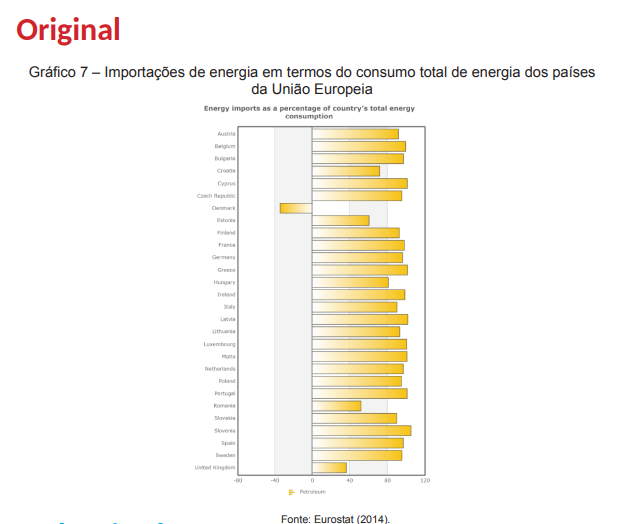

```r
knitr::include_graphics("https://github.com/ipeadata-lab/ipeaplot/blob/master/tests/compara_editorial/prints_original/grafico7.png?raw=true")
```

Gráfico 7 - Padrão Ipea

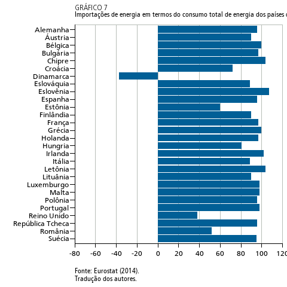

```r
base_graf7$pais<- factor(base_graf7$pais, levels=rev(sort(base_graf7$pais)))
graf7 <- ggplot(data=base_graf7, aes(x=pais, y=petroleo)) +
  geom_bar(stat="identity", fill = '#015f96') +
  coord_flip() +
  labs(x="",
       y="",
       fill = "",
       title="GRÁFICO 7",
       subtitle="Importações de energia em termos do consumo total de energia dos países da União Europeia",
       caption = 'Fonte: Eurostat (2014).\nTradução dos autores.') +
  theme_ipea(legend.position = 'none', geom = 'bar', direction = 'horizontal',
             y = -80, yend = 120)
graf7
```

Gráfico 8 - Original

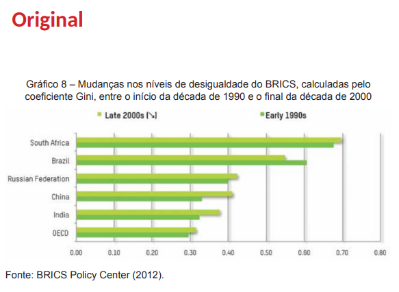

```r
knitr::include_graphics("https://github.com/ipeadata-lab/ipeaplot/blob/master/tests/compara_editorial/prints_original/grafico8.png?raw=true")
```

Gráfico 8 - Padrão Ipea

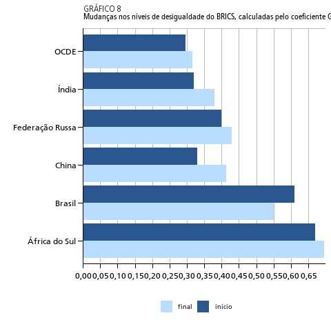

```r
base_graf8<- melt(base_graf8, id=c("pais"))

graf8 <- ggplot(data=base_graf8, aes(x=pais, y=value, group=variable, fill=variable)) +
  geom_bar(position='dodge',stat="identity") +
  coord_flip()+
  labs(x="",
       y="",
       fill = "",
       title="GRÁFICO 8",
       subtitle="Mudanças nos níveis de desigualdade do BRICS, calculadas pelo coeficiente Gini, entre o início da década de 1990 e o final da década de 2000",
       caption = '') +
  theme_ipea(legend.position = 'bottom', geom = 'bar',
             direction = 'horizontal', yend = 0.7) +
  scale_fill_ipea(discrete = T)
graf8
```

Gráfico 9 - Original

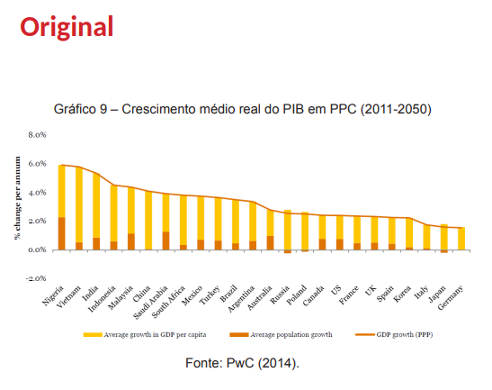

```r
knitr::include_graphics("https://github.com/ipeadata-lab/ipeaplot/blob/master/tests/compara_editorial/prints_original/grafico9.png?raw=true")
```

Gráfico 9 - Padrão Ipea

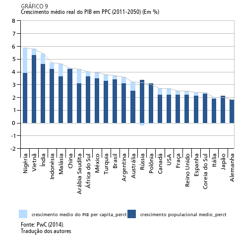

```r
######## GRAFICO 9
base_graf9_aux <- base_graf9[,c(1,4)]
base_graf9_aux$n <- 1:nrow(base_graf9_aux)
base_graf9<- melt(base_graf9[,-4], id=c("pais"))

base_graf9 <- base_graf9 %>%
  group_by(variable) %>%
  mutate(n = 1:n())

label <- (base_graf9 %>% ungroup() %>% distinct(pais))$pais

graf9 <-
  ggplot() +
  geom_bar(data=base_graf9, aes(x=n, y=value,
                                group=variable, fill=variable),
           stat="identity", width = 0.5) +
  labs(x="",
       y="",
       fill = "",
       title="GRÁFICO 9",
       subtitle="Crescimento médio real do PIB em PPC (2011-2050) (Em %)",
       caption = 'Fonte: PwC (2014).\nTradução dos autores') +
  geom_line(data=base_graf9_aux, aes(x=n ,y=`crescimento do PIB (ppc)_perct`, group = 1), color = 'gray') +
  scale_x_continuous(breaks = 1:max(base_graf9$n), labels = label) +
  scale_fill_ipea(discrete = T) +
  theme_ipea(legend.position = 'bottom',y = -2, yend = 8, angle = 90, adjust_ticks = T) +
  geom_rug(data=base_graf9, aes(x = n-0.5),
           outside = TRUE, sides = "b", length = unit(5, "mm"), linewidth = 0.25) +
  coord_cartesian(expand = FALSE, clip = "off")

graf9
```

Gráfico 10 - Original

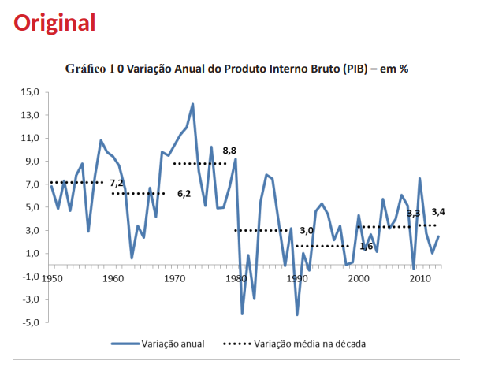

```r
knitr::include_graphics("https://github.com/ipeadata-lab/ipeaplot/blob/master/tests/compara_editorial/prints_original/grafico10.png?raw=true")
```

Gráfico 10 - Padrão Ipea

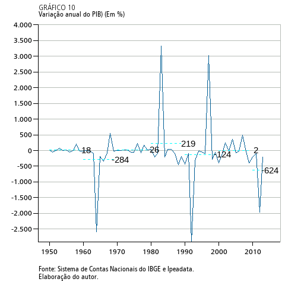

```r
base_graf10 <- base_graf10 %>%
  mutate(PIB = as.numeric(PIB),
         variacao_PIB = ((PIB/lag(PIB,1)) - 1)*100,
         decada = paste0(substr(Data,3,3),"0")) %>%
  group_by(decada) %>%
  mutate(media_variacao = mean(variacao_PIB, na.rm = T)) %>%
  filter(Data >= 1950)

text <- base_graf10 %>%
  arrange(-Data) %>%
  group_by(decada) %>% slice(1)

geom_segment <- base_graf10 %>%
  group_by(decada) %>%
  filter(Data == min(Data) | Data == max(Data)) %>%
  mutate(intervals = ifelse(Data == min(Data),'start_dates','end_dates')) %>%
  ungroup() %>%
  select(c(Data,intervals,media_variacao)) %>%
  tidyr::pivot_wider(names_from = 'intervals', values_from = 'Data')

graf10 <-
  ggplot() +
  geom_line(data=base_graf10, aes(x = Data, y= variacao_PIB,
                                group=1),
            color = '#015f96') +
  geom_segment(data = geom_segment,
               aes(x = start_dates, xend = end_dates,
                   y =media_variacao, yend = media_variacao),
               color = 'cyan', linetype = 'dashed')  +
  geom_text(data = text, aes(x = Data+2,
                             y= media_variacao, label = round(media_variacao,0))) +
  labs(x="",
       y="",
       fill = "",
       title="GRÁFICO 10",
       subtitle="Variação anual do PIB) (Em %)",
       caption = 'Fonte: Sistema de Contas Nacionais do IBGE e Ipeadata.\nElaboração do autor.') +
  theme_ipea(legend.position = 'bottom', yend = 4000, x_breaks = 10)

graf10
```